# Gsynth implementation

### 3. (extended)

#### Support for predictors

```
Not a data frame.
```

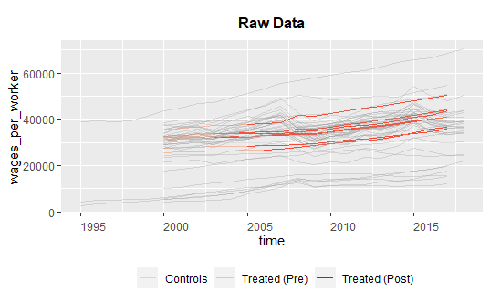

```r
panelView(wages_per_worker ~ is_announced_2y, data = n2_dta,
          index = c("geo","time"), type = "outcome")
```

```
Not a data frame.
```

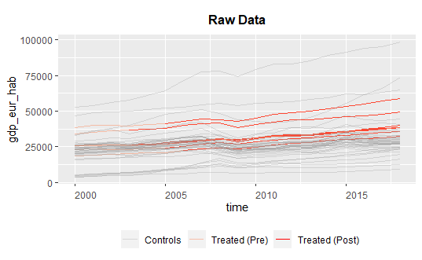

```r
panelView(gdp_eur_hab ~ is_announced_2y, data = n2_dta,
          index = c("geo","time"), type = "outcome")
```

```
Not a data frame.
```

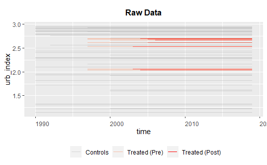

```r
panelView(urb_index ~ is_announced_2y, data = n2_dta,
          index = c("geo","time"), type = "outcome")
```

```
Not a data frame.
```

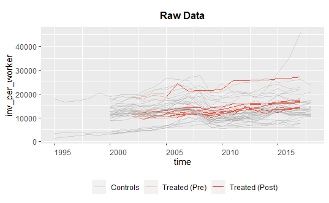

```r
panelView(inv_per_worker ~ is_announced_2y, data = n2_dta,
          index = c("geo","time"), type = "outcome")
```

#### Factor analysis

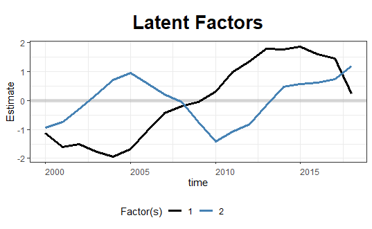

```r
# Know the donor pool of each treated:
weights_result <- out_n2$wgt.implied %>%
  as_tibble(rownames = "NUTS_ID")

# temp <- n2_dta %>%
#   left_join(weights_result, by = c("geo" = "NUTS_ID")) %>%
#   # filter(treated_uz == TRUE)
#   filter(geo == "DE30" | !(is.na(DE30))) %>%
#   filter(time >= 2000 & time <= 2008) %>%
#   group_by(geo == "DE30", time) %>%
#   mutate(DE30 = DE30-mean(DE30)/sd(DE30)) %>%
#   mutate(DE30 = ifelse(geo == "DE30", mean(DE30, na.rm = TRUE), DE30)) %>%
#   dplyr::summarise(mean_unem = weighted.mean(gdp_eur_hab,
#                                              DE30, na.rm = TRUE))
# # %>%
# #   pivot_wider(id_cols = time, names_from = `geo == "DE30"`,
# #               values_from = mean_unem)
#
#   select(geo, time, DE30, unempR_T); temp
# temp
# temp %>%
#   ggplot() +
#   geom_line(aes(x= time, y = mean_unem, color = `geo == "DE30"`))
#
# out_n2$lambda.co # estimated loadings of each factor
# out_n2$lambda.tr # estimated loadings of each factor
# out_n2$wgt.implied
#
# MASS::ginv(t(as.matrix(out_n2$lambda.tr)))
plot(out_n2, type = "factors", theme.bw = TRUE)
```

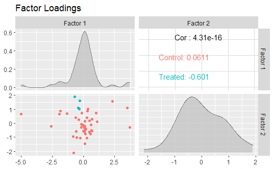

```r
plot(out_n2, type = "loadings")
```

Regarding factors’ evolution:

Regarding factor loadings:

“Another reassuring finding shown by Figure 3b is that the estimated factor loadings of the nine treated units mostly lie in the convex hull of those of the control units, which indicates that the treated counterfactuals are produced mostly by more reliable interpolations instead of extrapolations.” (paper Gsynth)

#### Maps

```r
donor_pool <- nuts_treated %>%
  filter(LEVL_CODE == 2) %>%
  left_join(weights_result) %>%
  filter(!is.na(DE30))

donor_pool %>% as.data.frame() %>%
  select(NUTS_ID, DE30, DE92, DE21) %>%
  arrange(desc(DE30))


leaflet() %>% addTiles() %>%
  addPolygons(data = donor_pool, weight = 0.5, color = "black",
              fillColor = ~colorQuantile("RdYlGn",
                      donor_pool$DE92)(donor_pool$DE92),
              popup = paste0(
                "<b>", donor_pool$NUTS_ID, "</b> <br/>",
                "<b> Weight Berlin </b>", donor_pool$DE30, "<br/>",
                "<b> Weight Hannover </b>", donor_pool$DE92, "<br/>")
              )
```

### 4. R. Un+co+Not_optimal

- Filter countries that have strong shocks of unemployment -> YES https://data.worldbank.org/indicator/SL.UEM.TOTL.NE.ZS?locations=DE-ES-GR-PL-NL-PT-LU-CZ-HU
- Filter regions -> YES
- 60km buffer arround each city center
- Filter regions with high unemployment rates that are not compatiable if I am using fixed effects by region. -> YES

```r
n2_dta <- main_dta %>%
  filter(treated_uz | contr_restr_60km) %>%
  filter(!(country %in% c("ES", "EL", "PT", "PL", "TR"))) %>%
  filter(!(geo %in% not_optimal_treated)) %>%
  group_by(geo) %>%
  filter(mean(unempR_T, na.rm = TRUE) < 15) %>%
  filter(
    # mean(wages_per_worker, na.rm = TRUE) < ,
    mean(wages_per_worker, na.rm = TRUE) > 10000
  ) %>%
  filter(
    mean(inv_per_worker, na.rm = TRUE) < 25000,
    # mean(inv_per_worker, na.rm = TRUE) > 5000
  ) %>%
  filter(
    # mean(gdp_eur_hab, na.rm = TRUE) < 65000,
    mean(gdp_eur_hab, na.rm = TRUE) > 5000
  ) %>%
  ungroup()

out_n2 <- gsynth(unempR_T ~ unempR_T ~ is_announced_2y + wages_per_worker + gdp_eur_hab, # inv_per_worker (only since 2002)
               data = n2_dta,
               index = c("geo","time"),
               na.rm = TRUE, # remove
               force = "two-way", # unit or time fixed effects or both?
               # CV = TRUE,
               r = c(0, 3), # an integer specifying the number of factors. If CV = TRUE, the cross validation procedure will select the optimal number of factors from r to 5.
               se = TRUE,
               EM = TRUE, # Gobillon and Magnac (takes a lot of time)
               inference = "parametric",
               # estimator = "mc",
               nboots = 200,  #500
               parallel = TRUE, cores = 5, # if do parallel and how many cores
               min.T0 = 5) # Has to be larger than r.max+1
```

```
Some treated units has too few pre-treatment periods.
They will be automatically removed.
Parallel computing ...
Cross-validating ...

 r = 0; sigma2 = 3.15341; IC = 1.16779; MSPE = 2.90835
 r = 1; sigma2 = 1.35178; IC = 0.94807; MSPE = 2.64881
 r = 2; sigma2 = 0.92344; IC = 1.17504; MSPE = 0.40905*
 r = 3; sigma2 = 0.58747; IC = 1.31149; MSPE = 0.46746

 r* = 2


Bootstrapping ...

list of removed treated units: DE13 DE50 DED5
```

```r
out_n2 %>% print()
```

```
Call:
gsynth.formula(formula = unempR_T ~ unempR_T ~ is_announced_2y +
    wages_per_worker + gdp_eur_hab, data = n2_dta, na.rm = TRUE,
    index = c("geo", "time"), force = "two-way",
    r = c(0, 3), EM = TRUE, se = TRUE, nboots = 200, inference = "parametric",
    parallel = TRUE, cores = 5, min.T0 = 5)

Average Treatment Effect on the Treated:
 ATT.avg   S.E. CI.lower CI.upper p.value
    -1.7 0.3984   -2.493  -0.9779       0

   ~ by Period (including Pre-treatment Periods):
        ATT   S.E. CI.lower CI.upper p.value n.Treated
-4  0.13756 0.2835  -0.4587   0.6743    0.69         0
-3 -0.06810 0.2745  -0.5425   0.4887    0.90         0
-2 -0.11021 0.3081  -0.7533   0.4070    0.69         0
-1 -0.03598 0.2630  -0.6060   0.4413    0.81         0
0   0.09972 0.2599  -0.3218   0.7153    0.53         0
1   0.08490 0.6804  -1.3459   1.2143    0.90         3
2   0.37000 0.9452  -1.6826   1.8337    0.85         3
3  -0.29184 1.2073  -2.6781   2.2927    0.75         3
4   0.14294 1.0235  -1.7042   2.2706    0.72         3
5  -0.05593 0.8922  -1.6459   1.9856    0.88         3
6  -0.22247 0.9474  -2.0817   1.8440    0.74         3
7  -1.07124 0.8517  -2.6769   0.5714    0.15         3
8  -2.70759 0.7734  -4.4326  -1.3526    0.00         3
9  -3.39672 0.6501  -4.7554  -2.2134    0.00         3
10 -3.89366 0.5626  -5.0804  -2.9019    0.00         3
11 -3.74014 0.5088  -4.7427  -2.6569    0.00         3
12 -3.32782 0.5997  -4.6254  -2.3496    0.00         3
13 -5.14427 0.8227  -6.6432  -3.6701    0.00         2
14      NaN     NA       NA       NA     NaN         0

Coefficients for the Covariates:
                       beta      S.E.   CI.lower   CI.upper
wages_per_worker -0.0001191 4.447e-05 -0.0003167 -1.350e-04
gdp_eur_hab      -0.0001006 3.220e-05 -0.0001042  1.975e-05
                 p.value
wages_per_worker    0.00
gdp_eur_hab         0.12
```

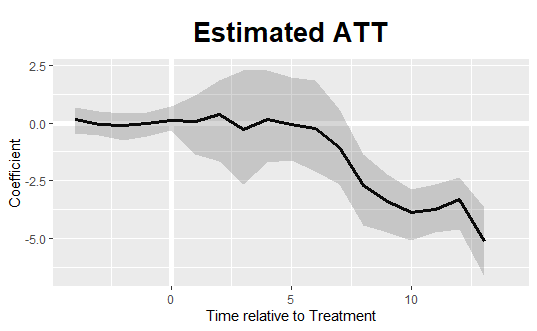

```r
plot(out_n2)#, ylim = c(-5000, 2000))
```

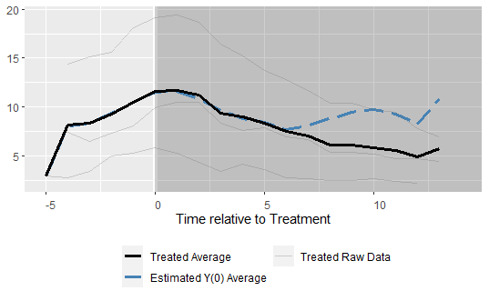

```r
# plot all data:
plot(out_n2, type = "counterfactual",
     raw = "all", main="") # Why the final dip
```

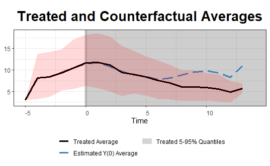

```r
# We can also add two 5 to 95% quantile bands of the treated and control outcomes as references to make sure the estimated counterfactuals are not results of severe extrapolations.

plot(out_n2, type = "counterfactual",
     raw = "band", xlab = "Time",
     # ylim = c(-5,35),
     theme.bw = TRUE)
```

```
DE13 not in the treatment groupDEB3 not in the treatment groupDE50 not in the treatment groupDED5 not in the treatment group
```

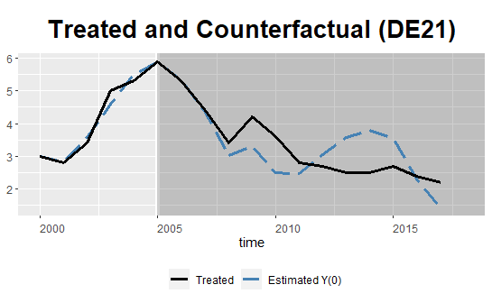

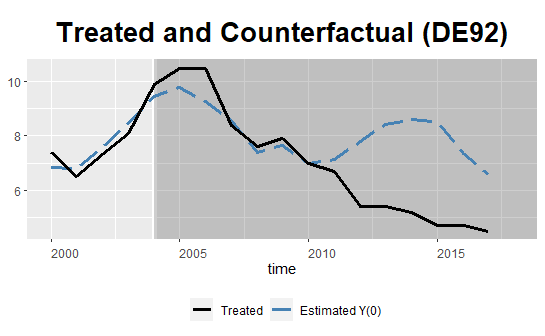

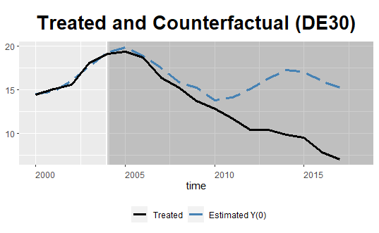

```r
for (i in n2_dta[n2_dta$treated_uz == TRUE, ]$geo %>% unique()){
  plot(out_n2, type = "counterfactual", id = i) # Berlin
}
```

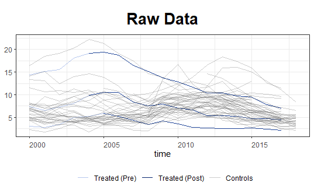

```r
plot(out_n2, type = "raw", theme.bw = TRUE)
```

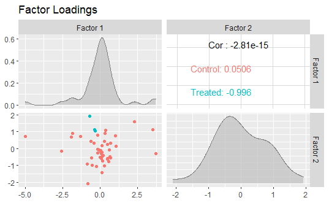

```r
plot(out_n2, type = "loadings")
```

**Conclusions** * GOOD parallel trends in average AND in specific cities * LOW differences in raw data, possibly relevant if I’m doing unit FE.

### 5. R. Un+co+Nop (NO unit FE)

- Filter countries that have strong shocks of unemployment -> YES https://data.worldbank.org/indicator/SL.UEM.TOTL.NE.ZS?locations=DE-ES-GR-PL-NL-PT-LU-CZ-HU
- Filter regions -> YES
- 60km buffer arround each city center
- Filter regions with high unemployment rates that are not compatiable if I am using fixed effects by region. -> YES

```r
n2_dta <- main_dta %>%
  filter(treated_uz | contr_restr_60km) %>%
  filter(!(country %in% c("ES", "EL", "PT", "PL", "TR"))) %>%
  filter(!(geo %in% not_optimal_treated)) %>%
  group_by(geo) %>%
  filter(mean(unempR_T, na.rm = TRUE) < 15) %>%
  filter(
    # mean(wages_per_worker, na.rm = TRUE) < ,
    mean(wages_per_worker, na.rm = TRUE) > 10000
  ) %>%
  filter(
    mean(inv_per_worker, na.rm = TRUE) < 25000,
    # mean(inv_per_worker, na.rm = TRUE) > 5000
  ) %>%
  filter(
    # mean(gdp_eur_hab, na.rm = TRUE) < 65000,
    mean(gdp_eur_hab, na.rm = TRUE) > 5000
  ) %>%
  ungroup()

out_n2 <- gsynth(unempR_T ~ unempR_T ~ is_announced_2y + wages_per_worker   + gdp_eur_hab, # inv_per_worker (only since 2002)
               data = n2_dta,
               index = c("geo","time"),
               na.rm = TRUE, # remove
               force = "time", # unit or time fixed effects or both?
               # CV = TRUE,
               r = c(0, 3), # an integer specifying the number of factors. If CV = TRUE, the cross validation procedure will select the optimal number of factors from r to 5.
               se = TRUE,
               EM = TRUE, # Gobillon and Magnac (takes a lot of time)
               inference = "parametric",
               # estimator = "mc",
               nboots = 200,  #500
               parallel = TRUE, cores = 5, # if do parallel and how many cores
               min.T0 = 5) # Has to be larger than r.max+1
```

```
Some treated units has too few pre-treatment periods.
They will be automatically removed.
Parallel computing ...
Cross-validating ...

 r = 0; sigma2 = 7.95196; IC = 2.09272; MSPE = 35.06907
 r = 1; sigma2 = 2.85481; IC = 1.69565; MSPE = 1.75129
 r = 2; sigma2 = 1.33276; IC = 1.54194; MSPE = 0.95127
 r = 3; sigma2 = 1.00126; IC = 1.84468; MSPE = 0.62387

 r* = 3


Bootstrapping ...

list of removed treated units: DE13 DE50 DED5
```

```r
out_n2 %>% print()
```

```
Call:
gsynth.formula(formula = unempR_T ~ unempR_T ~ is_announced_2y +
    wages_per_worker + gdp_eur_hab, data = n2_dta, na.rm = TRUE,
    index = c("geo", "time"), force = "time",
    r = c(0, 3), EM = TRUE, se = TRUE, nboots = 200, inference = "parametric",
    parallel = TRUE, cores = 5, min.T0 = 5)

Average Treatment Effect on the Treated:
 ATT.avg   S.E. CI.lower CI.upper p.value
 0.01684 0.3886  -0.4523    1.075    0.35

   ~ by Period (including Pre-treatment Periods):
         ATT   S.E. CI.lower CI.upper p.value n.Treated
-4  0.367881 0.2390 -0.15346   0.7657    0.12         0
-3 -0.226039 0.2600 -0.74801   0.2094    0.29         0
-2  0.099957 0.2635 -0.55020   0.5391    0.97         0
-1 -0.101961 0.2540 -0.57906   0.3590    0.70         0
0   0.002449 0.2404 -0.33956   0.5819    0.58         0
1   0.430732 0.7626 -0.88137   2.0681    0.48         3
2   1.534315 1.0625 -0.66643   3.4992    0.12         3
3   1.636772 1.2679 -0.77068   4.2682    0.15         3
4   2.574531 1.1716  0.41303   4.7628    0.03         3
5   2.188998 1.2107 -0.02412   4.5043    0.06         3
6   1.453993 1.2700 -1.21110   3.9898    0.24         3
7   0.826960 0.8933 -0.76110   2.6800    0.24         3
8  -1.161428 0.8082 -2.21313   1.1193    0.37         3
9  -1.914579 0.7987 -2.68426   0.3053    0.14         3
10 -2.668796 0.9203 -3.53631  -0.1731    0.05         3
11 -2.465729 0.9975 -3.50952   0.3140    0.07         3
12 -2.087616 0.9883 -3.50611   0.2627    0.17         3
13 -0.202226 1.1218 -1.68944   2.2717    0.82         2
14       NaN     NA       NA       NA     NaN         0

Coefficients for the Covariates:
                       beta      S.E.   CI.lower   CI.upper
wages_per_worker -3.668e-05 2.212e-05 -7.574e-05  1.467e-05
gdp_eur_hab      -4.539e-05 2.497e-05 -1.028e-04 -2.786e-06
                 p.value
wages_per_worker    0.18
gdp_eur_hab         0.03
```

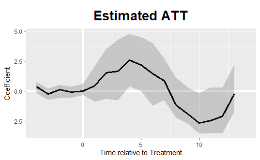

```r
plot(out_n2)#, ylim = c(-5000, 2000))
```

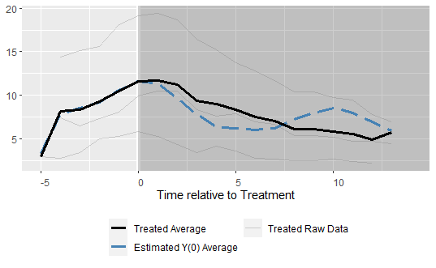

```r
# plot all data:
plot(out_n2, type = "counterfactual",
     raw = "all", main="") # Why the final dip
```

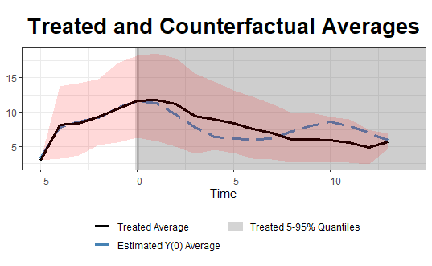

```r
# We can also add two 5 to 95% quantile bands of the treated and control outcomes as references to make sure the estimated counterfactuals are not results of severe extrapolations.

plot(out_n2, type = "counterfactual",
     raw = "band", xlab = "Time",
     # ylim = c(-5,35),
     theme.bw = TRUE)
```

```
DE13 not in the treatment groupDEB3 not in the treatment groupDE50 not in the treatment groupDED5 not in the treatment group
```

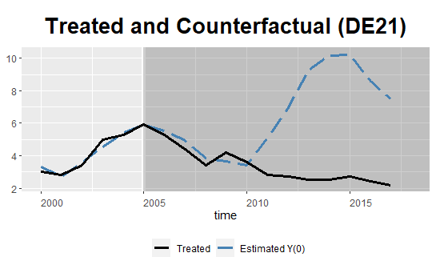

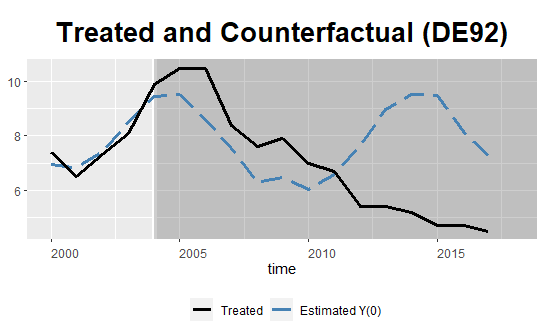

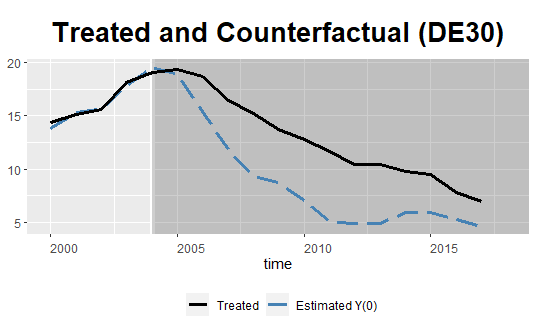

```r
for (i in n2_dta[n2_dta$treated_uz == TRUE, ]$geo %>% unique()){
  plot(out_n2, type = "counterfactual", id = i) # Berlin
}
```

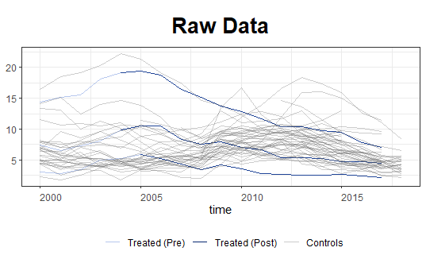

```r
plot(out_n2, type = "raw", theme.bw = TRUE)
```

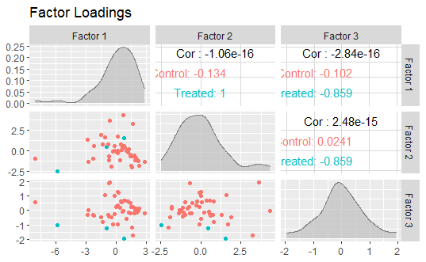

```r
plot(out_n2, type = "loadings")
```

**Conclusions**

- BAD parallel trends in average AND MEH in specific cities
- LOW differences in raw data, Not relevant given i don’t have UNIT FE.

### 6. Only german (or german + NL + Belgium controls)

- Have to do it with point or 30km restrictions

```r
n2_dta <- main_dta %>%
  filter(treated_uz | contr_restr_30km) %>%
  filter(country %in% c("DE", "NL", "BE")) %>%
  filter(!(country %in% c("ES", "EL", "PT", "PL", "TR")))

  # # filter(!(geo %in% not_optimal_treated)) %>%
  # group_by(geo) %>%
  # filter(mean(unempR_T, na.rm = TRUE) < 15) %>%
  # filter(
  #   # mean(wages_per_worker, na.rm = TRUE) < ,
  #   mean(wages_per_worker, na.rm = TRUE) > 10000
  # ) %>%
  # filter(
  #   mean(inv_per_worker, na.rm = TRUE) < 25000,
  #   # mean(inv_per_worker, na.rm = TRUE) > 5000
  # ) %>%
  # filter(
  #   # mean(gdp_eur_hab, na.rm = TRUE) < 65000,
  #   mean(gdp_eur_hab, na.rm = TRUE) > 5000
  # ) %>%
  # ungroup()

out_n2 <- gsynth(unempR_T ~ is_announced + wages_per_worker  + gdp_eur_hab + activity_rate, # inv_per_worker (only since 2002)
               data = n2_dta,
               index = c("geo","time"),
               na.rm = TRUE, # remove
               force = "two-way", # unit or time fixed effects or both?
               # CV = TRUE,
               r = c(0, 2), # an integer specifying the number of factors. If CV = TRUE, the cross validation procedure will select the optimal number of factors from r to 5.
               se = TRUE,
               EM = TRUE, # Gobillon and Magnac (takes a lot of time)
               inference = "parametric",
               # estimator = "mc",
               nboots = 200,  #500
               parallel = TRUE, cores = 5, # if do parallel and how many cores
               min.T0 = 5) # Has to be larger than r.max+1
```

```
Some treated units has too few pre-treatment periods.
They will be automatically removed.
Parallel computing ...
Cross-validating ...

 r = 0; sigma2 = 1.97146; IC = 0.75233; MSPE = 1.20015
 r = 1; sigma2 = 0.37737; IC = -0.09194; MSPE = 1.11879
 r = 2; sigma2 = 0.25702; IC = 0.28399; MSPE = 0.63519

 r* = 2


Bootstrapping ...

list of removed treated units: DED5
```

```r
out_n2 %>% print()
```

```
Call:
gsynth.formula(formula = unempR_T ~ is_announced + wages_per_worker +
    gdp_eur_hab + activity_rate, data = n2_dta, na.rm = TRUE,
    index = c("geo", "time"), force = "two-way",
    r = c(0, 2), EM = TRUE, se = TRUE, nboots = 200, inference = "parametric",
    parallel = TRUE, cores = 5, min.T0 = 5)

Average Treatment Effect on the Treated:
 ATT.avg  S.E. CI.lower CI.upper p.value
   -1.17 0.198   -1.219    -0.41       0

   ~ by Period (including Pre-treatment Periods):
        ATT    S.E. CI.lower CI.upper p.value n.Treated
-5  0.12135 0.14968  -0.1454  0.41532    0.40         0
-4 -0.03765 0.14349  -0.3769  0.20213    0.72         0
-3 -0.05721 0.12942  -0.3149  0.16052    0.55         0
-2 -0.30892 0.13364  -0.6326 -0.11682    0.01         0
-1  0.08425 0.12018  -0.1126  0.32573    0.40         0
0   0.27133 0.09214   0.1961  0.54948    0.00         0
1  -0.14815 0.16936  -0.2597  0.36277    0.84         6
2  -0.28084 0.21825  -0.4739  0.37689    0.84         6
3  -0.45392 0.26505  -0.6898  0.35151    0.63         6
4  -0.77716 0.29478  -0.8792  0.25328    0.26         6
5  -0.95828 0.29523  -1.1936 -0.04708    0.03         6
6  -1.44057 0.32290  -1.7133 -0.46683    0.00         6
7  -1.59004 0.33631  -1.8804 -0.60199    0.00         6
8  -1.51023 0.34051  -1.7842 -0.37440    0.00         6
9  -1.66554 0.32339  -1.9145 -0.65576    0.00         6
10 -1.49750 0.32286  -1.7264 -0.41192    0.00         6
11 -2.68125 0.34517  -2.8917 -1.56029    0.00         4
12 -2.29216 0.44200  -2.6382 -0.83668    0.00         2

Coefficients for the Covariates:
                       beta      S.E.   CI.lower   CI.upper
wages_per_worker  0.0002348 3.194e-05  0.0002762  0.0003895
gdp_eur_hab      -0.0005131 2.755e-05 -0.0006273 -0.0005230
activity_rate    -0.0119525 7.582e-04 -0.0161698 -0.0132358
                 p.value
wages_per_worker       0
gdp_eur_hab            0
activity_rate          0
```

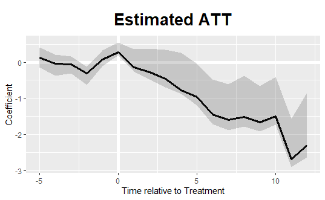

```r
plot(out_n2)#, ylim = c(-5000, 2000))
```

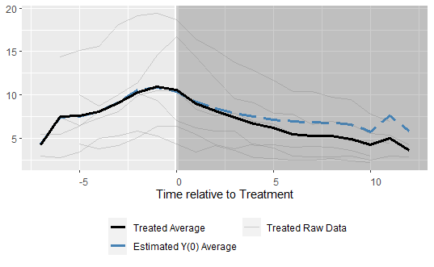

```r
# plot all data:
plot(out_n2, type = "counterfactual",
     raw = "all", main="") # Why the final dip
```

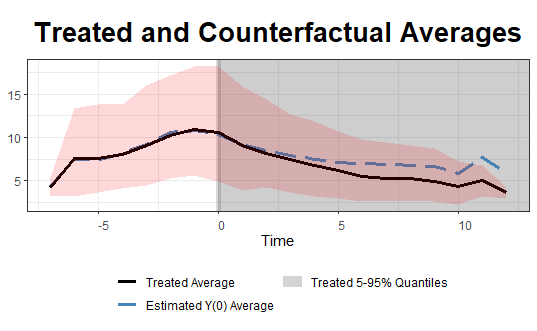

```r
# We can also add two 5 to 95% quantile bands of the treated and control outcomes as references to make sure the estimated counterfactuals are not results of severe extrapolations.

plot(out_n2, type = "counterfactual",
     raw = "band", xlab = "Time",
     # ylim = c(-5,35),
     theme.bw = TRUE)
```

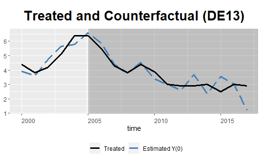

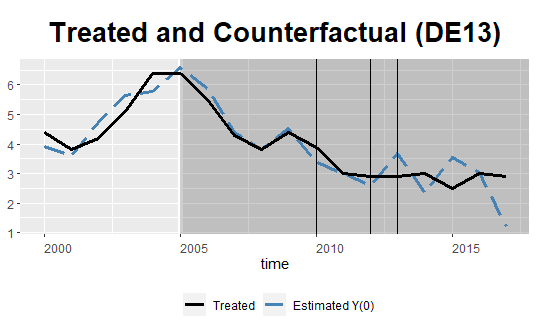

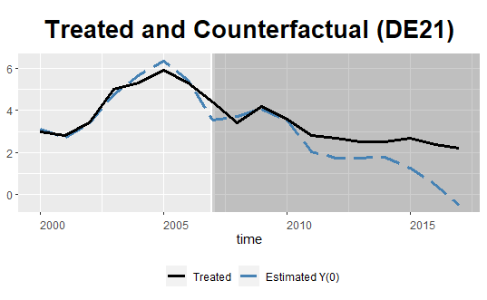

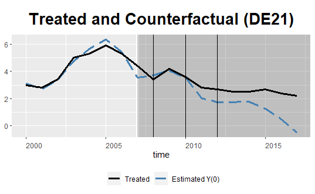

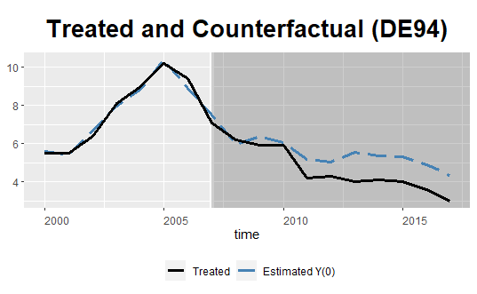

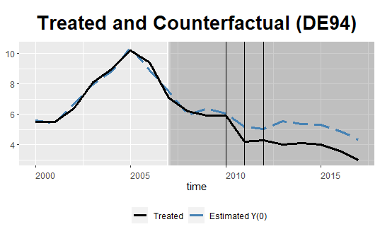

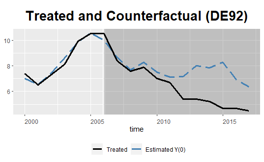

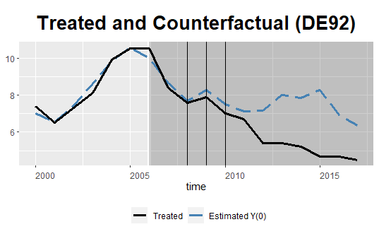

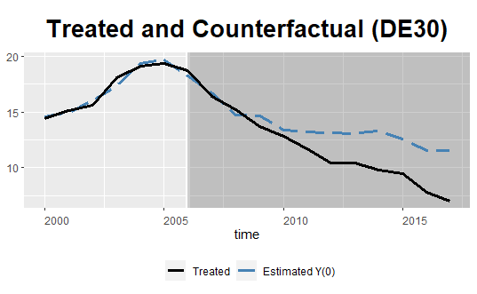

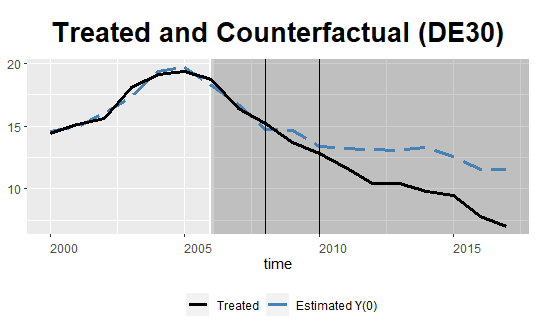

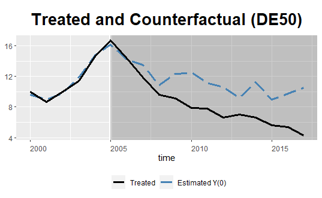

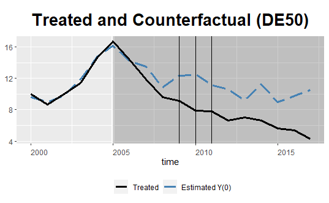

```r
for (i in n2_dta[n2_dta$treated_uz == TRUE, ]$geo %>% unique()){
  if (i %in% out_n2$id.tr){
    temp <- plot(out_n2, type = "counterfactual", id = i)
    print(temp +
            geom_vline(xintercept = n2_dta[n2_dta$geo == i,
                                           ]$year_stage1[1]) +
            geom_vline(xintercept = n2_dta[n2_dta$geo == i,
                                           ]$year_stage2[1]) +
            geom_vline(xintercept = n2_dta[n2_dta$geo == i,
                                           ]$year_stage3[1]))
  }
}
```

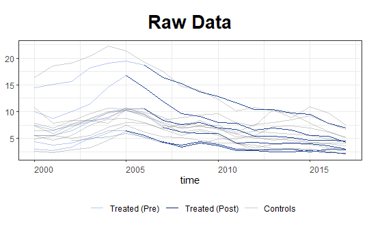

```r
plot(out_n2, type = "raw", theme.bw = TRUE)
```

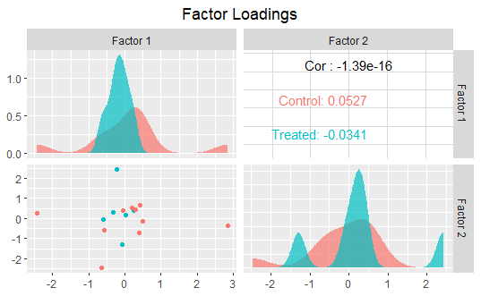

```r
plot(out_n2, type = "loadings")
```

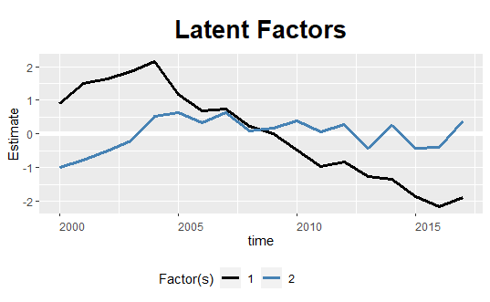

```r
plot(out_n2, type = "factors")
```

```r
out_n2$est.ind
```

```
, , DE13

           EFF      S.E.    CI.lower    CI.upper p.value
-5  0.47320773 0.3407218 -0.06402307  1.16186083    0.11
-4  0.18134196 0.4013003 -0.48932770  1.02956465    0.47
-3 -0.54117492 0.2352271 -1.14013092 -0.22406731    0.00
-2 -0.54420624 0.3198730 -1.30581606 -0.10946525    0.03
-1  0.62995094 0.3370291  0.09022514  1.33790410    0.04
0  -0.18111194 0.2797641 -0.78327055  0.30839103    0.54
1  -0.37444753 0.4377387 -1.12867688  0.56350139    0.53
2  -0.10196549 0.2752660 -0.59066641  0.45639387    0.72
3  -0.02478761 0.5357743 -1.07139831  1.05776935    0.90
4  -0.13975467 0.6210374 -1.26733165  1.16805459    0.97
5   0.53128046 0.6279476 -0.34529086  1.93671220    0.24
6   0.00627808 0.6619530 -1.35538558  1.07888375    0.88
7   0.28479387 0.5407537 -0.83067743  1.14439407    0.73
8  -0.78292030 0.6521103 -2.01620779  0.53243506    0.19
9   0.62399728 0.7553118 -0.70908018  2.21961909    0.43
10 -1.04284771 0.6476247 -2.63776944 -0.03035902    0.05
11 -0.02512767 0.5561011 -1.53846194  0.64597824    0.55
12  1.68065944 0.5669058  0.45763018  2.57578122    0.00

, , DE21

           EFF      S.E.    CI.lower  CI.upper p.value
-5 -0.13366656 0.4286703 -0.80998833 0.8628922    0.96
-4  0.09846513 0.4814878 -0.77165698 1.0564734    0.94
-3  0.02310046 0.2615113 -0.50138077 0.4994402    0.98
-2  0.25944020 0.3448884 -0.42775142 0.8892022    0.51
-1 -0.35903472 0.3869794 -1.25319550 0.1692612    0.16
0  -0.43715278 0.3019188 -0.93643476 0.1545686    0.20
1  -0.14872204 0.2439278 -0.46226527 0.4340845    0.76
2   0.83789811 0.1882788  0.64277919 1.3376169    0.00
3  -0.33730955 0.5090149 -1.26597852 0.7310153    0.62
4   0.14231910 0.5694339 -0.86789588 1.4479324    0.58
5   0.03664395 0.6376177 -1.02546455 1.3758440    0.71
6   0.74655917 0.6869052 -0.15782682 2.3192798    0.15
7   0.95156355 0.6687787 -0.01403497 2.4743664    0.07
8   0.77295080 0.7450444 -0.35007159 2.4472922    0.15
9   0.72979181 0.8010237 -0.72632992 2.3760350    0.25
```

[output cut: 76 more lines]

```
-2  0.13845361 0.3233453 -0.54260631  0.68135825    0.77
-1  0.15346938 0.3592647 -0.43775579  0.84549205    0.50
0  -0.17959593 0.3115309 -0.82663029  0.39996077    0.47
1   0.51321332 0.2466447  0.05996478  0.98829904    0.04
2  -0.42729596 0.1856455 -0.74322573 -0.02992539    0.04
3   0.22647754 0.4832579 -0.60073092  1.28740840    0.40
4  -0.47617703 0.5596783 -1.33706225  0.77703823    0.57
5  -0.17639501 0.6161261 -1.19103665  1.21883059    0.92
6  -0.98064027 0.6629328 -2.10002650  0.64129813    0.16
7  -0.72198602 0.6300463 -1.71543562  0.76199104    0.33
8  -1.53990052 0.6985792 -2.89752280 -0.06512386    0.04
9  -1.27097831 0.7073635 -2.50023306  0.29279642    0.07
10 -1.31234328 0.7020639 -2.54429940  0.18680826    0.09
11 -1.27610288 0.6271106 -2.38609219  0.14821213    0.08
12 -1.31719332 0.5876972 -2.40331651 -0.04065258    0.05
```